# Praktikum 6 Anreg

# Eksplorasi Data

## Peubah Respon

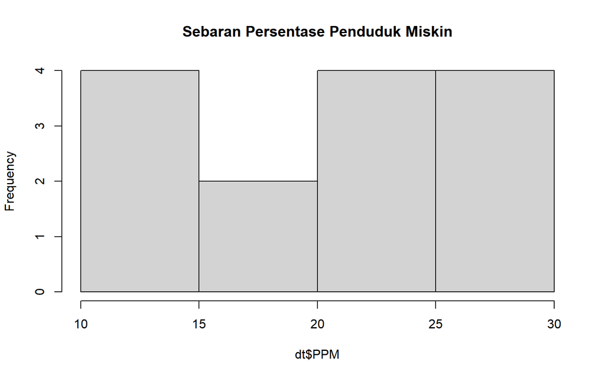

```r
hist(dt$PPM, main = "Sebaran Persentase Penduduk Miskin")
```

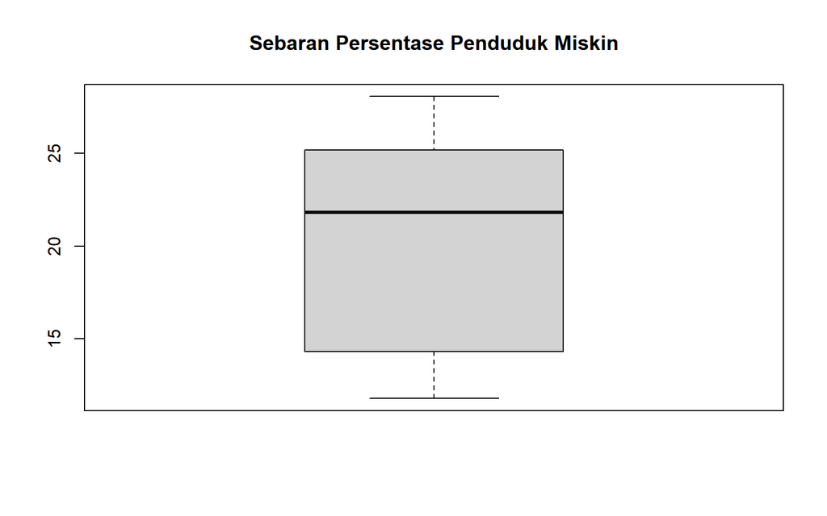

```r
boxplot(dt$PPM, main = "Sebaran Persentase Penduduk Miskin")
```

## Peubah Pennjelas vs Peubah Respon

### IPM

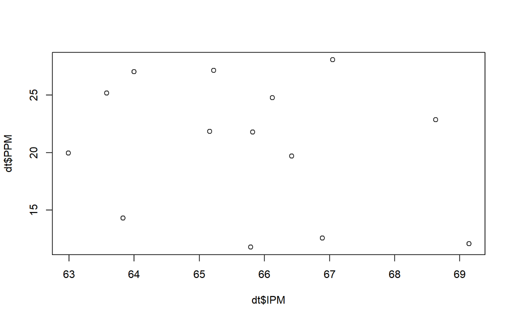

```r
plot(dt$IPM, dt$PPM)
```

Hubungan antara peubah IPM dan PPM cenderung tidak linear.

### RLS

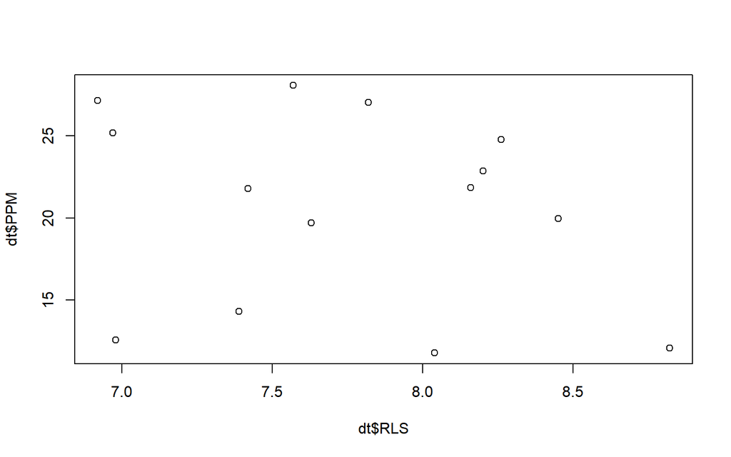

```r
plot(dt$RLS, dt$PPM)
```

Hubungan antara peubah RLS dan PPM cenderung tidak linear

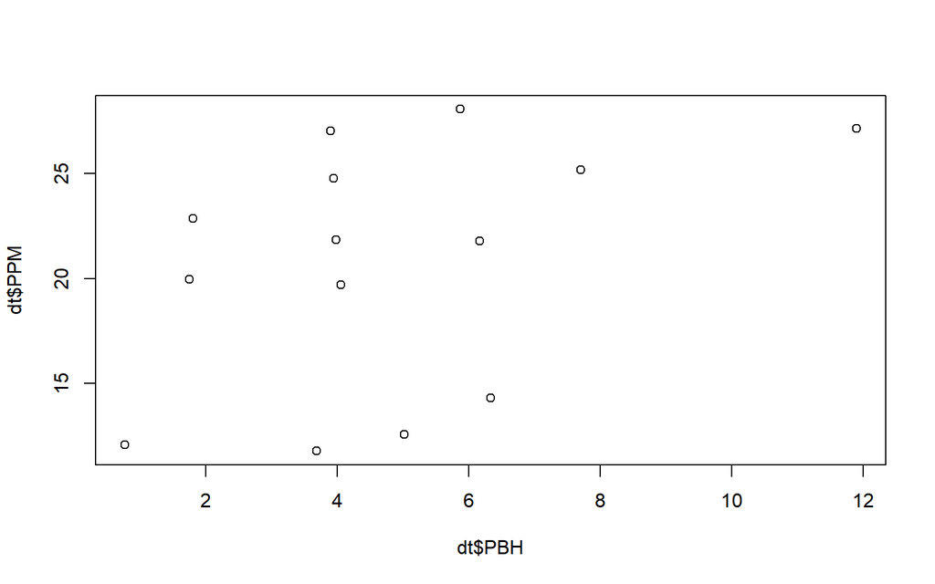

```r
plot(dt$PBH, dt$PPM)
```

Hubungan antara peubah PBH dan PPM tidak linear, ada satu amatan dengan nilai yang jauh dari amatan lainnya

### PDRB

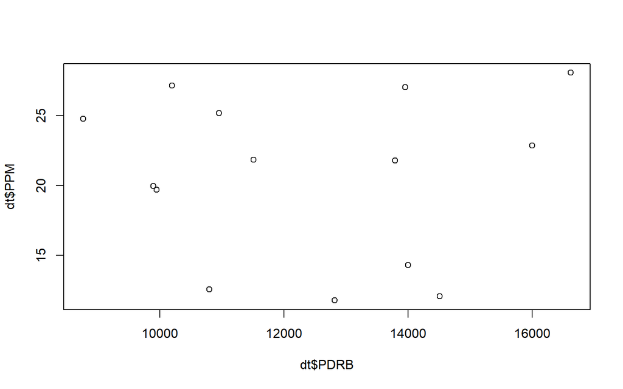

```r
plot(dt$PDRB, dt$PPM)
```

Hubungan antara peubah PDRB dan PPM cenderung tidak linear

# PKB

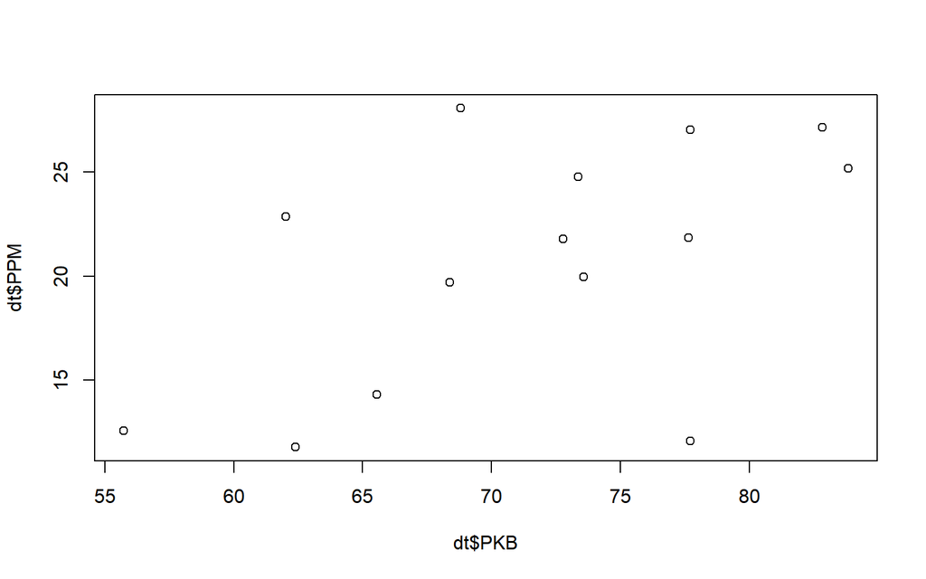

```r
plot(dt$PKB, dt$PPM)
```

Hubungan antara peubah PKB dan PPM cenderung tidak linear

## Korelasi

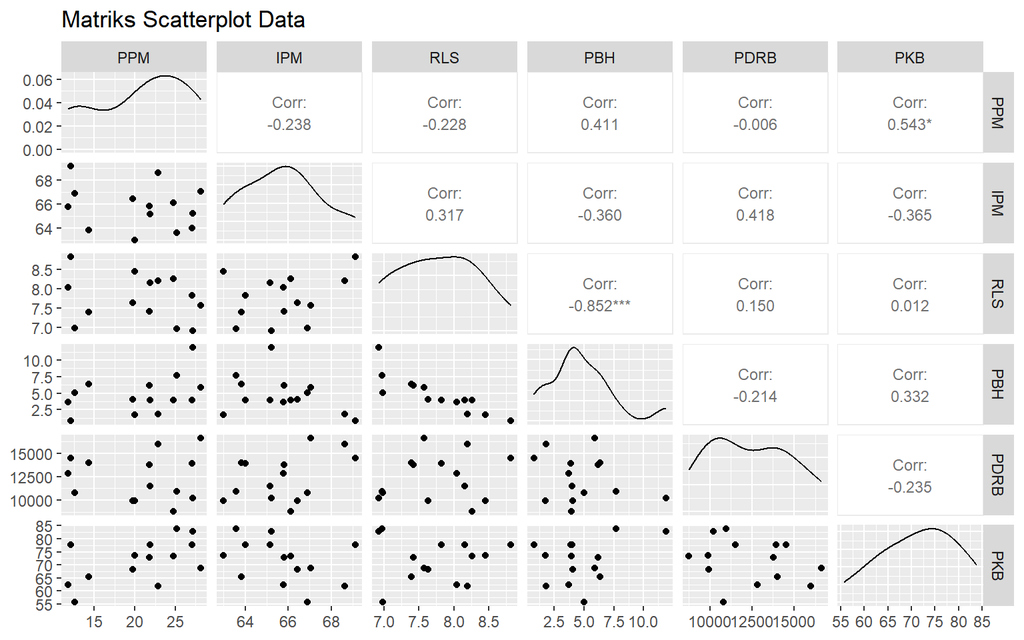

```r
ggpairs(dt,
        upper = list(continuous = wrap('cor', size = 3)),
        title = "Matriks Scatterplot Data")
```

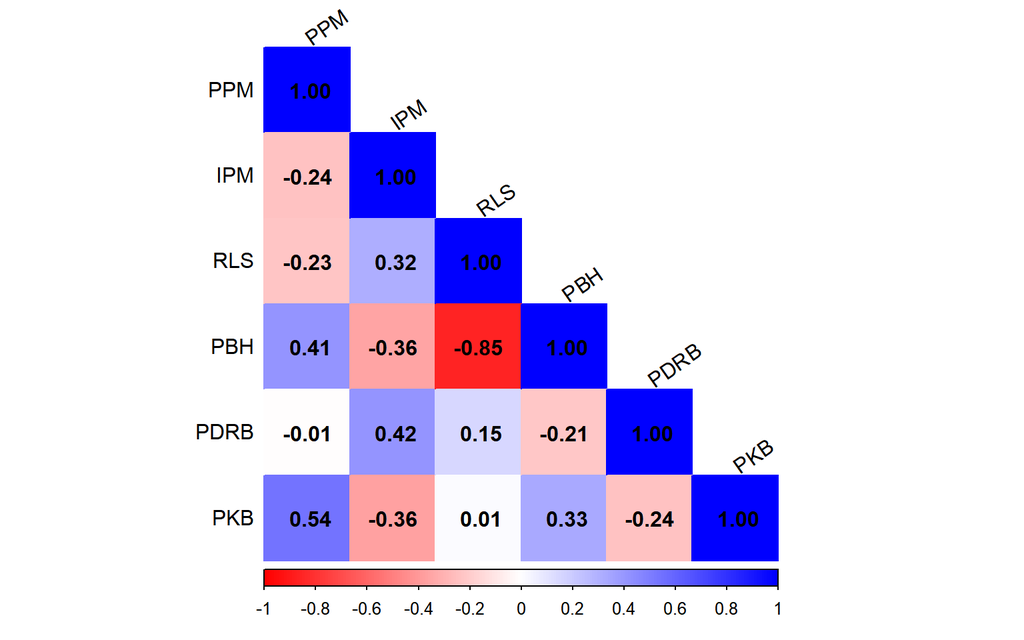

```r
cor_matrix <- cor(dt, use = "complete.obs")

corrplot(cor_matrix, method = "color", type = "lower",
         col = colorRampPalette(c("red", "white", "blue"))(200),
         addCoef.col = "black", tl.col = "black", tl.srt = 35)
```

Korelasi yang tinggi ini mengindikasikan adanya potensi multikolinearitas, yang dapat mempengaruhi keakuratan model yang akan dibentuk.

# Pemodelan

```r
model1 = lm(formula = PPM ~ ., data = dt)
summary(model1)
```

```
##
## Call:
## lm(formula = PPM ~ ., data = dt)
##
## Residuals:
##     Min      1Q  Median      3Q     Max
## -8.8683 -2.0302 -0.1493  3.2060  6.1390
##
## Coefficients:
##               Estimate Std. Error t value Pr(>|t|)
## (Intercept) -0.2061781 78.7949463  -0.003    0.998
## IPM         -0.0950754  1.0904496  -0.087    0.933
## RLS         -0.7958592  6.7630573  -0.118    0.909
## PBH          0.4191542  1.4686154   0.285    0.783
## PDRB         0.0004330  0.0007333   0.590    0.571
## PKB          0.3618409  0.2803997   1.290    0.233
##
## Residual standard error: 5.844 on 8 degrees of freedom
## Multiple R-squared:  0.3841, Adjusted R-squared:  -0.0009025
## F-statistic: 0.9977 on 5 and 8 DF,  p-value: 0.4759
```

Persamaan yang terbentuk adalah
$$\hat{PPM}=-0.2061−0.0950IPM−0.7958RLS+0.4191PBH+0.0004PDRB+0.3618PKB$$

# Pemeriksaan Multikolinearitas

## Perubahan Peubah

```r
mod1 <- lm(PPM ~ ., dt[1:2])
mod2 <- lm(PPM ~ ., dt[1:3])
mod3 <- lm(PPM ~ ., dt[1:4])
mod4 <- lm(PPM ~ ., dt[1:5])
mod5 <- lm(PPM ~ ., dt)

stargazer(mod1, mod2, mod3, mod4, mod5,
          type = "text", single.row = TRUE)
```

```
##
## ================================================================================================================
##                                                         Dependent variable:
##                     --------------------------------------------------------------------------------------------
##                                                                 PPM
##                            (1)                (2)                (3)                (4)               (5)
## ----------------------------------------------------------------------------------------------------------------
## IPM                   -0.762 (0.900)     -0.589 (0.978)     -0.348 (0.952)    -0.555 (1.068)    -0.095 (1.090)
## RLS                                      -1.681 (3.015)     4.465 (5.237)      4.680 (5.457)    -0.796 (6.763)
## PBH                                                         1.572 (1.117)      1.635 (1.167)     0.419 (1.469)
## PDRB                                                                          0.0004 (0.001)    0.0004 (0.001)
## PKB                                                                                              0.362 (0.280)
## Constant             70.781 (59.203)    72.444 (61.052)     1.382 (77.292)    8.166 (81.378)    -0.206 (78.795)
## ----------------------------------------------------------------------------------------------------------------
## Observations                14                 14                 14                14                14
## R2                        0.056              0.082              0.234              0.256             0.384
## Adjusted R2               -0.022             -0.084             0.004             -0.075            -0.001
## Residual Std. Error  5.906 (df = 12)    6.084 (df = 11)    5.830 (df = 10)    6.057 (df = 9)    5.844 (df = 8)
## F Statistic         0.718 (df = 1; 12) 0.494 (df = 2; 11) 1.018 (df = 3; 10) 0.774 (df = 4; 9) 0.998 (df = 5; 8)
## ================================================================================================================
## Note:                                                                                *p<0.1; **p<0.05; ***p<0.01
```

## Perubahan Banyak Data

```r
mod5_1 <- lm(PPM ~ ., dt[1:15,])
stargazer(summary(mod5)$coefficients, summary(mod5_1)$coefficients,
          type = "text",
          font.size = "small")
```

```
##
## ===================================================
##             Estimate Std. Error t value Pr(> | t| )
## ---------------------------------------------------
## (Intercept)  -0.206    78.795   -0.003     0.998
## IPM          -0.095    1.090    -0.087     0.933
## RLS          -0.796    6.763    -0.118     0.909
## PBH          0.419     1.469     0.285     0.783
## PDRB         0.0004    0.001     0.590     0.571
## PKB          0.362     0.280     1.290     0.233
## ---------------------------------------------------
##
## ===================================================
##             Estimate Std. Error t value Pr(> | t| )
## ---------------------------------------------------
## (Intercept)  -0.206    78.795   -0.003     0.998
## IPM          -0.095    1.090    -0.087     0.933
## RLS          -0.796    6.763    -0.118     0.909
## PBH          0.419     1.469     0.285     0.783
## PDRB         0.0004    0.001     0.590     0.571
## PKB          0.362     0.280     1.290     0.233
## ---------------------------------------------------
```

## Akar Ciri

```r
x <- dt[-1]
r <- cor(x)
(ev <- eigen(r)$values)
```

```
## [1] 2.35521935 1.23189750 0.80025525 0.53542158 0.07720632
```

```r
# Simultan
if ((max(ev) / min(ev)) <= 100) {
  cat("Tidak ada multikolinearitas\n")
} else if ((max(ev) / min(ev)) > 100 & (max(ev) / min(ev)) <= 1000) {
  cat("Ada multikolinearitas yang lemah\n")
} else {
  cat("Ada multikolinearitas yang kuat\n")
}
```

```
## Tidak ada multikolinearitas
```

```r
# Parsial
if (all((max(ev) / ev) <= 1000)) {
  cat("Tidak ada multikolinearitas\n")
} else {
  cat("Ada multikolinearitas pada peubah penjelas ke:", which((max(ev) / ev) > 1000), "\n")
}
```

```
## Tidak ada multikolinearitas
```

## Nilai VIF

```r
vif(model1)
```

```
##      IPM      RLS      PBH     PDRB      PKB
## 1.499374 6.064404 6.490002 1.228565 2.023596
```